# Lab_III

204814891, 204169320

6/10/2020

# Questoin 1

1.1

```r
# must input either n or x and not both
# x is a vector
# lambda is a constant
sample_data <- function(n=NA,x=NA,lambda,seed=123){
  set.seed(seed)
  if (is.na(n)){
    n <- length(x)
  }
  else{
    x <- runif(n,-2,2)
  }

  eps <- rnorm(n,mean=0,sd=sqrt(0.3))
  fx <- sin(lambda*x) + 0.3*(x^2) + ((x-0.5)/3)^3
  yx <- fx + eps
  return(data.frame(list(predictors=x,responses=yx)))
}
```

1.2

```r
# train_x, train_y are of shape (num_of_training_examples, 1)
# x is of shape (num_examples_to_smooth_on,1)
# h is a scalar
# returns list: y_hat is a vector with same shape of x; W is weights matrix of shape (num_of_training_examples,num_examples_to_smooth_on)

gaussian_kernel_regr <- function(train_x,train_y,x,h){
  # in the next two functions x is a scalar

  # apply kernel function to one example and find its weights
  gaussian_kernel_weights <- function(x, train_x, h){
  kernels <- dnorm(x=x,mean = train_x, sd=h)
  w_hat <- kernels/sum(kernels)
  return(w_hat)}

  # fit mu_hat to one example
  gaussian_kernel_preds <- function(train_y, w_hat){
  mu_hat <- sum(train_y*w_hat)
  return(mu_hat)}

  # generalize to all smoothers
  w_mat <- mapply(FUN=gaussian_kernel_weights, x, MoreArgs = list(train_x=train_x, h=h))
  mu_vec <-  apply(w_mat,2,FUN=function(w)gaussian_kernel_preds(train_y,w))
  return(list(y_hat=mu_vec,W=w_mat))
}
```

1.3 sample 4 experiments. We’ve chosen h values between 10^(-3) and 2.

```r
exps <- list(
  exp1 = list(n=50, lambda=1.5, data=sample_data(n=50,lambda=1.5)),
  exp2 = list(n=50, lambda=5, data=sample_data(n=50,lambda=5)),
  exp3 = list(n=200, lambda=1.5, data=sample_data(n=200,lambda=1.5)),
  exp4 = list(n=200, lambda=5, data=sample_data(n=200,lambda=5))
  )

h_values <- c(0.001,0.5,1,2)
```

The next code block will help us in organizing our results.

```r
# empty constructor with determination of colnames
create_empty_df <- function(rows,cols){
  df <- data.frame(matrix(nrow=length(rows),ncol=length(cols)),row.names = rows)
  colnames(df) <- cols
  return(df)
}

# index will include what n and lambda were used
combinations <- rep(NA,4)
for (i in 1:4){
  key.exp <- paste("exp",i,sep='')
  ex <- exps[[key.exp]]
  combinations[i] <- paste('n=',ex$n,'lambda=',ex$lambda,sep=',')
}

#initialization
epes <- create_empty_df(combinations,h_values)
eops <- create_empty_df(combinations,h_values)
errins <- create_empty_df(combinations,h_values)
errs_kfold <- create_empty_df(combinations,h_values)
errs_new <- create_empty_df(combinations,h_values)
```

The next functions will be Helpers for computing the whole experiments’s regressions. 1.3.1 EPE

```r
epe <- function(y,y_hat){
  return((sum(y-y_hat,na.rm=T)^2)/length(y))
}
```

1.3.2 Eop Note about W and sigma^2: W is the weight matrix of our training example (and therfore indeed squared). In a Kernel Regression, we can think about the smoothing as weighting every response by the corresponding kernel distance between the observation and the predictor. In the Gaussian Kernel Regression, the kernel distance is the normal density. sigma^2 is 0.3 as given, this is the noise of the data. It’s basically the variance of the responses (y).

```r
eop <- function(n,trW,sigma=sqrt(0.3)){
  return(2*(sigma^2)*trW/n)
}
```

1.3.3 ERRin

```r
errin <- function(train_x,lambda,h,num_of_samples=10){
  errs <- rep(NA,num_of_samples)
  for (i in 1:num_of_samples){
    y_star <- sample_data(x=train_x,lambda=lambda)$responses
    reg <- gaussian_kernel_regr(train_x=train_x,train_y=y_star,x=train_x,h=h)
    y_hat <- reg$y_hat
    errs[i] <- epe(y_star,y_hat)
  }
  return(sum(errs)/length(errs))
}
```

1.3.4 kfold Cross-Validation for Kernel Regression

```r
kfold_kernel_regr <- function(data,k=5,h){
  # random partitioning
  x <- data$predictors
  y <- data$responses
  n <- nrow(data)
  fold_size <- n/k # we should consider cases in which n/k isn't integer but we're given that it's indeed integer
  idxs <- 1:n
  errs <- rep(NA,k)
  for (i in 1:k){
    fold <- sample(idxs,fold_size)
    train_x <- x[-fold]
    train_y <- y[-fold]
    test_x <- x[fold]
    test_y <- y[fold]
    reg <- gaussian_kernel_regr(train_x,train_y,test_x,h)
    y_hat_test <- reg$y_hat
    errs[i] <- sum((test_y - y_hat_test)^2,na.rm=T)/length(test_y)
  }
  estimation <- mean(errs)
  return(estimation)
}
```

1.3.5 Out-of-Sample Expected Prediction Error

```r
new_sample_err <- function(train_x,train_y,lambda,h,n=10,seed=321){
  df <- sample_data(n=n,lambda=lambda,seed=seed)
  test_x <- df$predictors
  test_y <- df$responses
  reg <- gaussian_kernel_regr(train_x,train_y,x=test_x,h=h)
  y_hat <- reg$y_hat
  return(sum((test_y - y_hat)^2,na.rm = T)/length(test_y))
}
```

Using the previous functions we can compute the different error quantities in all of our regressions.

```r
for (i in 1:4){
  key.exp <- paste("exp",i,sep='')
  ex <- exps[[key.exp]]
  df <- ex$data
  train_x <- ex$data$predictors
  train_y <- ex$data$responses
  lambda <- ex$lambda
  n <- ex$n

  # compute by specific value of h
  h_epes <- rep(NA,4)
  h_eops <- rep(NA,4)
  h_errins <- rep(NA,4)
  h_errs_kfold <- rep(NA,4)
  h_errs_new <- rep(NA,4)

  j=1
  for (h in h_values){
    reg <- gaussian_kernel_regr(train_x=train_x, train_y=train_y, x=train_x, h=h)
    W <- reg$W
    trW <- sum(diag(W))
    y_hat <- reg$y_hat

    h_epes[j] <- epe(train_y,y_hat)
    h_eops[j] <- eop(n,trW)
    h_errins[j] <- errin(train_x,lambda,h)
    h_errs_kfold[j] <- kfold_kernel_regr(data=df,k=5,h=h)
    h_errs_new[j] <- new_sample_err(train_x,train_y,lambda,h)

    j=j+1
  }
  epes[i,] <- h_epes
  eops[i,] <- h_eops
  errins[i,] <- h_errins
  errs_kfold[i,] <- h_errs_kfold
  errs_new[i,] <- h_errs_new
}
```

Visualizations

```r
plot_list <- list()
for (i in 1:4){
  key.exp <- paste("exp",i,sep='')
  ex <- exps[[key.exp]]
  # set df to plot with 1 setup, all errors time and h_values colunm
  df <- data.frame(h_values,as.numeric(epes[i,]),as.numeric(eops[i,]),as.numeric(errins[i,]),as.numeric(errs_kfold[i,]),as.numeric(errs_new[i,]))
colnames(df) <- c("h","EPE","Eop","ERRin","Err-kfold","Err-Out-Sample")
df <- melt(df,id="h")
p <- ggplot(df) +
  geom_line(aes(h,value,colour=variable)) +
  theme(legend.title = element_blank()) +
  xlab("bandwidth") + ylab("error") +
  ggtitle(paste("n=",ex$n," lambda=",ex$lambda))
plot_list[[i]] = p
}
```

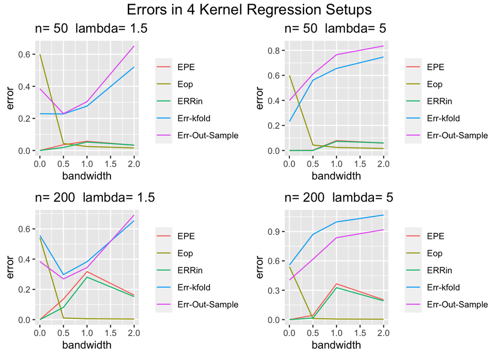

```r
grid.arrange(
  plot_list[[1]],plot_list[[2]],plot_list[[3]],plot_list[[4]],
  nrow=2,ncol=2,
  top=textGrob("Errors in 4 Kernel Regression Setups",gp=gpar(fontsize=15))
  )
```

Eop: This quantity represents overfitting on training data. Overfitting is mainly caused by introducing too much variance to the model, Therfore this quantity decreasing with a bandwidth increasing (namely model’s bias increasing).

k-fold and Out-of-Sample are slighthy going together, as they concerned about unseen data (in k-fold it’s the ‘test-fold’ which is originally part of the training, but it’s unseen to the model). We see underfitting in areas with a lot of bias in the model (higher bandwidth). In addition, smaller Lambdas has “sweet point”, and this may be caused since lambda parameter affect the amount of ‘constant noise’ (in contrast to the random noise of epsilon) in the data.

4 First of all we will write the given Quardradic Regression Model

```r
quard_regr <- function(train_x,train_y){
  reg <- lm(train_y~train_x+I(train_x^2))
  return(reg)
}
```

Because of the new model, we have to do some minor modifications to the ERRin, kfold and Out-of-Sample Err functions.

```r
quard_errin <- function(train_x,lambda,num_of_samples=10){
  errs <- rep(NA,num_of_samples)
  for (i in 1:num_of_samples){
    y_star <- sample_data(x=train_x,lambda=lambda)$responses
    reg <- quard_regr(train_x,train_y=y_star)
    y_hat <- reg$fitted.values
    errs[i] <- epe(y_star,y_hat)
  }
  return(sum(errs)/length(errs))
}

kfold_quard_regr <- function(data,k=5){
  # random partitioning
  x <- data$predictors
  y <- data$responses
  n <- nrow(data)
  fold_size <- n/k # we should consider cases in which n/k isn't integer but we're given that it's indeed integer
  idxs <- 1:n
  errs <- rep(NA,k)
  for (i in 1:k){
    fold <- sample(idxs,fold_size)
    train_x <- x[-fold]
    train_y <- y[-fold]
    test_x <- x[fold]
    test_y <- y[fold]
    reg <- quard_regr(train_x,train_y)
    test_X_mat <- matrix(c(rep(1,length(test_x)),test_x,I(test_x^2)),
                         nrow=length(test_x),ncol=3)
    y_hat_test <- test_X_mat %*% reg$coefficients
    errs[i] <- sum((test_y - y_hat_test)^2,na.rm=T)/length(test_y)
  }
  estimation <- mean(errs)
  return(estimation)
}

quard_new_sample_err <- function(train_x,train_y,lambda,n=10,seed=231){
  df <- sample_data(n=n,lambda=lambda,seed=seed)
  test_x <- df$predictors
  test_y <- df$responses
  reg <- quard_regr(train_x,train_y)
  y_hat <- reg$fitted.values
  return(sum((test_y - y_hat)^2,na.rm = T)/length(test_y))
}
```

Now, we’re able to compute the error quantities

```r
epes <- rep(NA,4)
eops <- rep(NA,4)
errins <- rep(NA,4)
errs_kfold <- rep(NA,4)
errs_new <- rep(NA,4)

for (i in 1:4){
  key.exp <- paste("exp",i,sep='')
  ex <- exps[[key.exp]]
  df <- ex$data
  train_x <- df$predictors
  train_y <- df$responses
  lambda <- ex$lambda
  n <- ex$n
  reg <- quard_regr(train_x,train_y)
  y_hat <- reg$fitted.values
  epes[i] <- epe(y=train_y,y_hat=y_hat)

  # get Px which equivalent to kernel's weights matrix
  design_mat <- matrix(c(rep(1,length(train_x)),train_x),
                       nrow=length(train_x),ncol=2)
  Px <- design_mat%*%solve(t(design_mat)%*%design_mat)%*%t(design_mat)
  trPx <- sum(diag(Px))
  eops[i] <- eop(n,trW)

  errins[i] <- quard_errin(train_x,lambda)

  errs_kfold[i] <- kfold_quard_regr(df,k=5)

  errs_new[i] <- quard_new_sample_err(train_x,train_y,lambda)
}
```

There is no bandwidth influention here, so we won’t benefit a lot from visualaizing. instead we’ll get a look from the tabular data.

```r
data.frame(epes,eops,errins,errs_kfold,errs_new, row.names = combinations)
```

```
##                            epes       eops       errins errs_kfold errs_new
## n=,50,lambda=,1.5  5.273196e-31 0.01550536 3.701637e-33  0.2743699  7.79562
## n=,50,lambda=,5    2.527205e-32 0.01550536 6.162976e-35  0.6117702  3.70074
## n=,200,lambda=,1.5 2.621672e-34 0.00387634 7.188495e-31  0.3475739 28.56398
## n=,200,lambda=,5   2.820748e-30 0.00387634 3.586948e-32  0.9366304 13.87284
```

# Questoin 2

first we want to import the data:

```r
covid_data <- read.csv('israel-covid19-data/IsraelCOVID19.csv')
# we will change the collom names to get rid of the hebrew
colnames(covid_data) <- c('Date', 'Total_Cases','New_cases', 'Moderate', 'severe', 'Deceased', 'Total_Recovered', 'New_Recovered', 'Tested_Today', 'Total_Tested',  'Percent_Positive', 'GF_Normalized_to_Tests',   'Baseline')
# we will also remove the last row since it has no information
covid_data <- covid_data[1:nrow(covid_data)-1,]
```

we want to make a figgure showing number of new cases per day, lets see it at a first glimps:

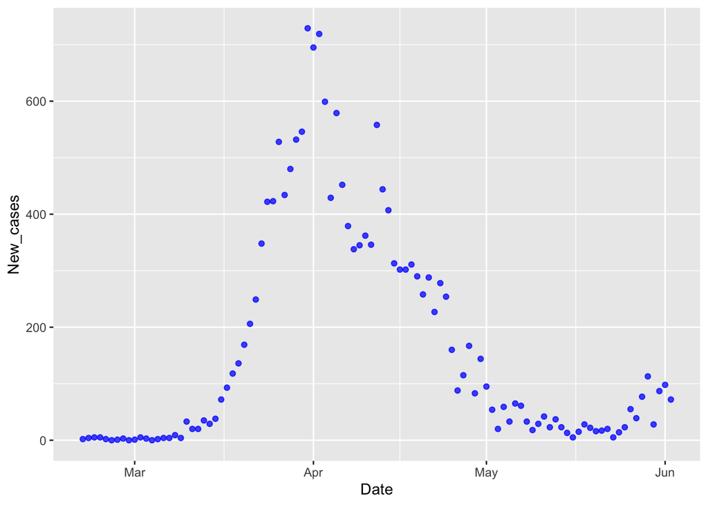

```r
covid_data$Date <- as.Date(covid_data$Date, format="%d/%m/%Y")
covid_fig <- ggplot(data = covid_data, aes(x = Date)) + geom_point(aes(y = New_cases),color = 'blue',  alpha = .75)
covid_fig
```

now we have our initial fig we need to calculate the regression curve using a loess model

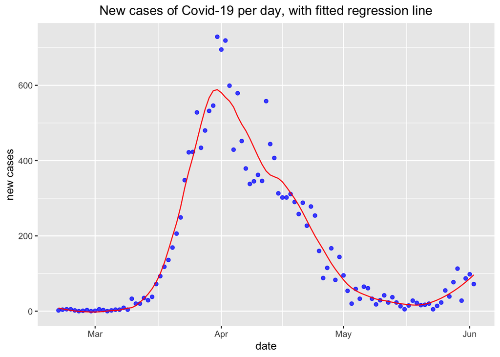

```r
# let's add a column with the day number of the pandemic (in the data)
covid_data <- covid_data[,1:3]
covid_data$day_number <- c(1:nrow(covid_data))
# now we can fit our regression curve, playing with different span levels gives different fits, 0.3 gives nive results.
reg_curve <- loess(covid_data$New_cases ~ covid_data$day_number , span = 0.3)

covid_fig <- covid_fig + geom_line(aes(y=reg_curve$fitted), color = 'red') +
  labs(title = 'New cases of Covid-19 per day, with fitted regression line', x = 'date',y = 'new cases') +
  theme(plot.title = element_text(hjust = 0.5))
covid_fig
```

Seif 2.2 Here we will want to look at the rate of new detections per day, to do this we will look at thefirst-derivative of the regression curve from part 1.

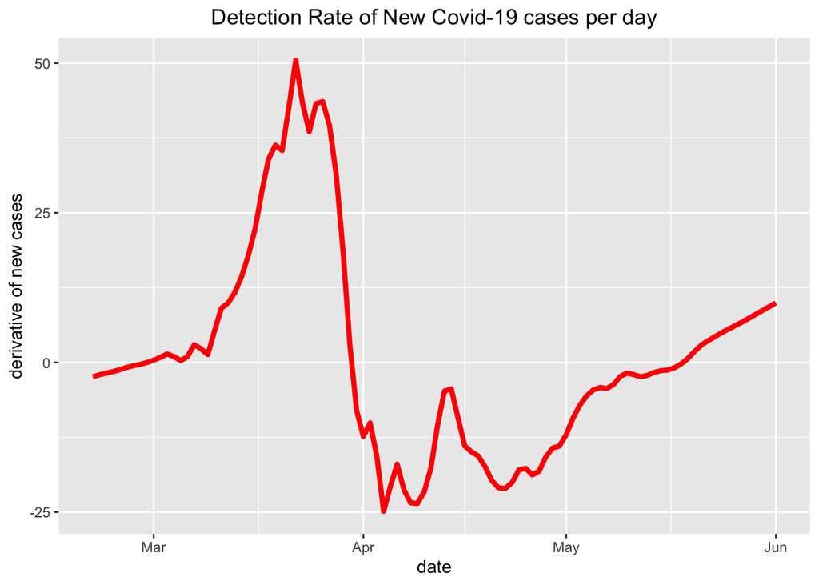

```r
derivative <- diff(reg_curve$fitted)/diff(covid_data$day_number)
deriv_df <- as.data.frame(cbind(covid_data[1:nrow(covid_data)-1,], derivative))

#dX <- rembed(X,2)) # centers the X values for plotting

ggplot(deriv_df) + geom_line(aes(Date, y = derivative), color = 'red', size=1.5) +
  labs(title = "Detection Rate of New Covid-19 cases per day", x = "date", y = "derivative of new cases") +
  theme(plot.title = element_text(hjust = 0.5))
```

Q3 FMRI data first thing we want to do is import the data

```r
raw_data <- load('fMRIclass_new.RData')
load("wavpyr.RData")
```